# Classifying Wins and Losses

Published

December 10, 2024

# Import Libraries

```r
library(tidyverse)
library(Hmisc)
library(corrplot)
library(GGally)
library(car)
library(smotefamily)
library(boot)
library(class)
library(MASS)
```

# Import Data

```r
df <- readRDS("Data/Cleaned/cleaned_moneypuck_games.rds")
write.csv(df, "../cleaned_moneypuck_games.csv", row.names = FALSE)
head(df, 10)
```

```
# A tibble: 10 × 111
   team  season name      gameId playerTeam opposingTeam home_or_away gameDate
   <chr>  <dbl> <chr>      <dbl> <chr>      <chr>        <chr>           <dbl>
 1 NYR     2023 NYR   2023020010 NYR        BUF          AWAY         20231012
 2 NYR     2023 NYR   2023020010 NYR        BUF          AWAY         20231012
 3 NYR     2023 NYR   2023020010 NYR        BUF          AWAY         20231012
 4 NYR     2023 NYR   2023020010 NYR        BUF          AWAY         20231012
 5 NYR     2023 NYR   2023020010 NYR        BUF          AWAY         20231012
 6 NYR     2023 NYR   2023020022 NYR        CBJ          AWAY         20231014
 7 NYR     2023 NYR   2023020022 NYR        CBJ          AWAY         20231014
 8 NYR     2023 NYR   2023020022 NYR        CBJ          AWAY         20231014
 9 NYR     2023 NYR   2023020022 NYR        CBJ          AWAY         20231014
10 NYR     2023 NYR   2023020022 NYR        CBJ          AWAY         20231014
# ℹ 103 more variables: position <chr>, situation <chr>,
#   xGoalsPercentage <dbl>, corsiPercentage <dbl>, fenwickPercentage <dbl>,
#   iceTime <dbl>, xOnGoalFor <dbl>, xGoalsFor <dbl>, xReboundsFor <dbl>,
#   xFreezeFor <dbl>, xPlayStoppedFor <dbl>, xPlayContinuedInZoneFor <dbl>,
#   xPlayContinuedOutsideZoneFor <dbl>, flurryAdjustedxGoalsFor <dbl>,
#   scoreVenueAdjustedxGoalsFor <dbl>, flurryScoreVenueAdjustedxGoalsFor <dbl>,
#   shotsOnGoalFor <dbl>, missedShotsFor <dbl>, blockedShotAttemptsFor <dbl>, …
```

# Create Target Variable: Goal Superiority

To create a “goal superiority” variable, we compare the variables goalsFor and goalsAgainst (the scoreboard score; the number of times the puck actually crossed the goal line into the opponent’s net during a game) and xGoalsFor and xGoalsAgainst (a statistical estimate of how many goals a team should have scored based on the quality of their scoring chances) to create this binary classification.

```r
df <- df |>
  filter(situation == "all") |>
  mutate(
    result = case_when(
      goalsFor > goalsAgainst ~ 1,
      goalsFor < goalsAgainst ~ 0,
      goalsFor == goalsAgainst ~ 0
    ),
    xresult = case_when(
      xGoalsFor > xGoalsAgainst ~ 1,
      xGoalsFor < xGoalsAgainst ~ 0,
      xGoalsFor == xGoalsAgainst ~ 0
    )
  ) |>
  filter(result != "OT")

table(df$result)
```

```
   0    1
1640 1466
```

```r
table(df$xresult)
```

```
   0    1
1553 1553
```

## Teams vs. Games

Is this data at the game level or team match-up level?

```r
unique_matchups <- df |>
  dplyr::select(playerTeam, opposingTeam, gameDate) |>
  distinct() |>
  arrange(playerTeam, opposingTeam, gameDate)     # Sort by the selected columns


matchup_counts <- unique_matchups |>
  group_by(playerTeam, opposingTeam) |>
  summarise(gameCount = n(), .groups = "drop") |> # Count unique game dates per matchup
  filter(gameCount > 1)                           # Filter for matchups with more than one game

# View matchups with multiple dates
matchup_counts
```

```
# A tibble: 992 × 3
   playerTeam opposingTeam gameCount
   <chr>      <chr>            <int>
 1 ANA        ARI                  3
 2 ANA        BOS                  2
 3 ANA        BUF                  2
 4 ANA        CAR                  2
 5 ANA        CBJ                  2
 6 ANA        CGY                  3
 7 ANA        CHI                  3
 8 ANA        COL                  4
 9 ANA        DAL                  3
10 ANA        DET                  2
# ℹ 982 more rows
```

```r
duplicates <- df |>
  dplyr::select(playerTeam, opposingTeam, gameDate) |>
  dplyr::group_by(playerTeam, opposingTeam, gameDate) |>
  dplyr::summarise(rowCount = n(), .groups = "drop") |>
  dplyr::filter(rowCount > 1)

# View duplicates
duplicates
```

```
# A tibble: 0 × 4
# ℹ 4 variables: playerTeam <chr>, opposingTeam <chr>, gameDate <dbl>,
#   rowCount <int>
```

This is game-level data

# Select Predictors

We should choose an initial set of predictors that we think are most related to scoring, which would be variables related to game context, offensive and defensive performance,

Here are a few definitions for variables where the meaning isn’t obvious:

- highDangerxGoalsFor & highDangerxGoalsAgainst: Goals from high danger shots
- shotAttemptsFor: Shot attempts. Includes shots on goal, missed shots, and blocked shot attempts
- corsiPercentage: Share of total shot attempts (measures a player’s ability to control the puck and create offensive opportunities)
- fenwickPercentage: measures a team’s unblocked shot attempts relative to their opponent’s
- dZoneGiveawaysFor: Giveaways in the team’s defensive zone. Giveaways shows how much a player has the puck and riskiness.
- xGoalsFromxReboundsOfShotsFor: Expected Goals from Expected Rebounds of player’s shots. Even if a shot does not actually generate a rebound, if it’s a shot that is likely to generate a rebound the player is credited with xGoalsFromxRebounds

```r
df <- df |> dplyr::select(xresult, playerTeam, opposingTeam, home_or_away, highDangerxGoalsFor, shotAttemptsFor, highDangerxGoalsAgainst, corsiPercentage, fenwickPercentage, dZoneGiveawaysFor, xGoalsFromxReboundsOfShotsFor)

glimpse(df)
```

```
Rows: 3,106
Columns: 11
$ xresult                       <dbl> 1, 1, 1, 0, 1, 0, 0, 0, 1, 0, 0, 1, 1, 1…
$ playerTeam                    <chr> "NYR", "NYR", "NYR", "NYR", "NYR", "NYR"…
$ opposingTeam                  <chr> "BUF", "CBJ", "ARI", "NSH", "SEA", "CGY"…
$ home_or_away                  <chr> "AWAY", "AWAY", "HOME", "HOME", "AWAY", …
$ highDangerxGoalsFor           <dbl> 2.544, 1.653, 0.468, 0.542, 0.569, 1.664…
$ shotAttemptsFor               <dbl> 57, 93, 61, 60, 48, 39, 58, 52, 51, 52, …
$ highDangerxGoalsAgainst       <dbl> 0.490, 1.459, 1.104, 2.455, 0.208, 0.678…
$ corsiPercentage               <dbl> 0.4831, 0.6643, 0.5351, 0.5660, 0.4898, …
$ fenwickPercentage             <dbl> 0.5309, 0.6465, 0.5476, 0.5135, 0.5405, …
$ dZoneGiveawaysFor             <dbl> 1, 0, 5, 4, 0, 1, 4, 5, 7, 3, 3, 7, 3, 3…
$ xGoalsFromxReboundsOfShotsFor <dbl> 0.579, 0.729, 0.499, 0.422, 0.390, 0.338…
```

# Variable Relationships

## Correlation w/ numeric vars

```r
png("corrplot_logreg.png", width = 400, height = 300)
corrplot(cor(df[map_lgl(df, is.numeric)]), method = "circle", order = "hclust", tl.cex = 0.65)
```

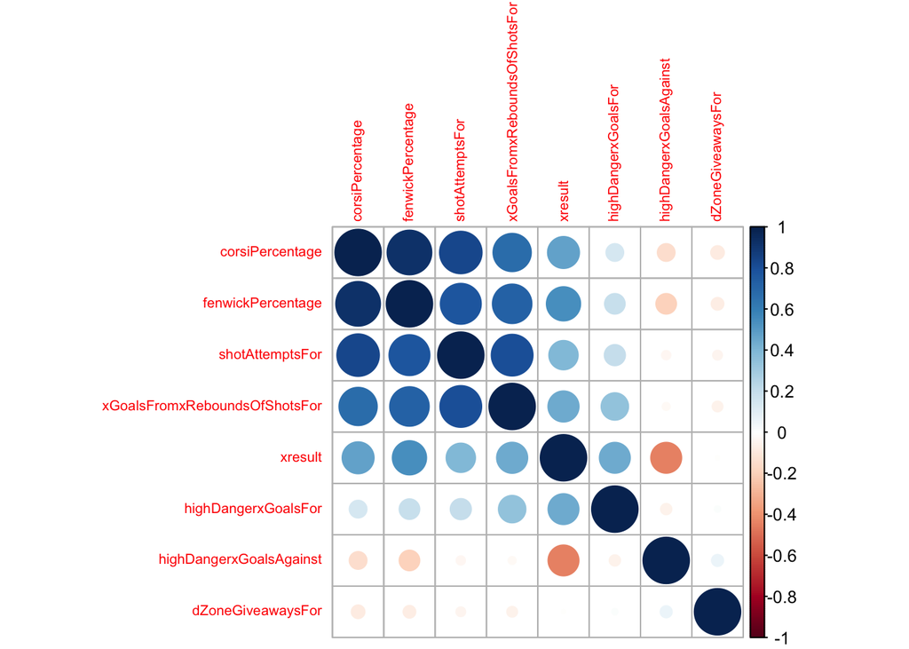

```r
corrplot(cor(df[map_lgl(df, is.numeric)]), method = "circle", order = "hclust", tl.cex = 0.65)
```

A few of these variables are correlated with each other, such as CorsiPercentage and shot attempst for, so not all of these variables are needed for the final models.

All variables except dZoneGiveawaysFor are significantly related to xresult.

## Categorical

```r
for (var in names(df)[map_lgl(df, is.character)]) {
  print(var)
  print(chisq.test(df$xresult, df[[var]]))
}
```

```
[1] "playerTeam"

    Pearson's Chi-squared test

data:  df$xresult and df[[var]]
X-squared = 204.83, df = 32, p-value < 2.2e-16

[1] "opposingTeam"

    Pearson's Chi-squared test

data:  df$xresult and df[[var]]
X-squared = 204.83, df = 32, p-value < 2.2e-16

[1] "home_or_away"

    Pearson's Chi-squared test with Yates' continuity correction

data:  df$xresult and df[[var]]
X-squared = 64.618, df = 1, p-value = 9.091e-16
```

All Categorical variables are significantly related to the xresult target variable.

# Variable Refinement

## First Logistic Model

```r
logreg.vars <- glm(xresult ~ shotAttemptsFor + highDangerxGoalsAgainst + highDangerxGoalsFor + xGoalsFromxReboundsOfShotsFor + corsiPercentage + fenwickPercentage + dZoneGiveawaysFor + playerTeam + opposingTeam + home_or_away, family = binomial, data = df)
summary(logreg.vars)
```

```
Call:
glm(formula = xresult ~ shotAttemptsFor + highDangerxGoalsAgainst +
    highDangerxGoalsFor + xGoalsFromxReboundsOfShotsFor + corsiPercentage +
    fenwickPercentage + dZoneGiveawaysFor + playerTeam + opposingTeam +
    home_or_away, family = binomial, data = df)

Coefficients:
                                Estimate Std. Error z value Pr(>|z|)
(Intercept)                   -1.707e+01  1.125e+00 -15.164  < 2e-16 ***
shotAttemptsFor               -4.139e-02  1.522e-02  -2.719 0.006547 **
highDangerxGoalsAgainst       -3.936e+00  1.915e-01 -20.552  < 2e-16 ***
highDangerxGoalsFor            3.709e+00  1.853e-01  20.012  < 2e-16 ***
xGoalsFromxReboundsOfShotsFor  6.281e+00  1.255e+00   5.005 5.59e-07 ***
corsiPercentage                3.170e+00  3.006e+00   1.054 0.291703
fenwickPercentage              2.730e+01  2.929e+00   9.321  < 2e-16 ***
dZoneGiveawaysFor              7.541e-04  2.652e-02   0.028 0.977318
playerTeamARI                  5.560e-01  6.427e-01   0.865 0.386960
playerTeamBOS                  1.643e+00  5.825e-01   2.821 0.004783 **
playerTeamBUF                  7.651e-01  6.245e-01   1.225 0.220572
playerTeamCAR                  1.385e+00  6.359e-01   2.178 0.029436 *
playerTeamCBJ                  1.010e+00  6.459e-01   1.564 0.117760
playerTeamCGY                  5.533e-01  6.335e-01   0.873 0.382440
playerTeamCHI                  1.007e+00  6.599e-01   1.527 0.126864
playerTeamCOL                  1.837e+00  6.103e-01   3.010 0.002610 **
playerTeamDAL                  2.330e+00  6.043e-01   3.855 0.000116 ***
playerTeamDET                  5.054e-01  6.126e-01   0.825 0.409399
playerTeamEDM                  1.574e+00  6.074e-01   2.592 0.009546 **
playerTeamFLA                  9.372e-01  6.065e-01   1.545 0.122304
playerTeamLAK                  1.895e+00  6.458e-01   2.934 0.003342 **
playerTeamMIN                  9.298e-01  6.040e-01   1.539 0.123687
playerTeamMTL                  1.318e+00  6.081e-01   2.168 0.030132 *
playerTeamNJD                  1.597e+00  6.563e-01   2.433 0.014965 *
playerTeamNSH                  1.457e+00  6.286e-01   2.318 0.020458 *
playerTeamNYI                  1.423e+00  6.225e-01   2.286 0.022254 *
playerTeamNYR                  1.580e+00  5.992e-01   2.636 0.008381 **
playerTeamOTT                  8.892e-01  6.243e-01   1.424 0.154344
playerTeamPHI                  8.928e-01  6.097e-01   1.464 0.143076
playerTeamPIT                  6.704e-01  6.156e-01   1.089 0.276124
playerTeamSEA                  1.770e+00  6.211e-01   2.849 0.004385 **
playerTeamSJS                  6.730e-01  6.636e-01   1.014 0.310556
```

[output cut: 36 more lines]

```
opposingTeamVAN               -1.850e+00  6.327e-01  -2.925 0.003448 **
opposingTeamVGK               -1.176e+00  5.964e-01  -1.972 0.048627 *
opposingTeamWPG               -1.380e+00  6.164e-01  -2.238 0.025196 *
opposingTeamWSH               -1.267e+00  6.158e-01  -2.058 0.039587 *
home_or_awayHOME               3.125e+00  1.975e-01  15.824  < 2e-16 ***
---
Signif. codes:  0 '***' 0.001 '**' 0.01 '*' 0.05 '.' 0.1 ' ' 1

(Dispersion parameter for binomial family taken to be 1)

    Null deviance: 4305.8  on 3105  degrees of freedom
Residual deviance: 1272.4  on 3033  degrees of freedom
AIC: 1418.4

Number of Fisher Scoring iterations: 8
```

All but corsipercentage and dZoneGiveawaysFor was significant.

# Model Assumptions

## Linearity

Plot the log-odds of xresult against all numeric variables

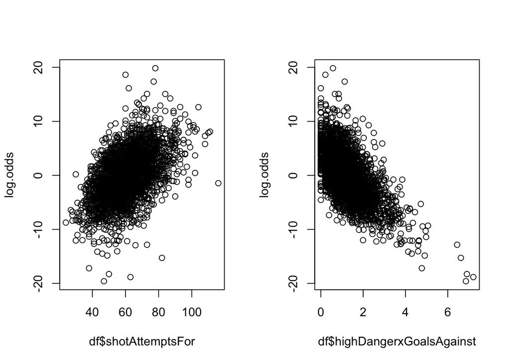

```r
par(mfrow = c(1, 2))

logreg.num <- glm(xresult ~ shotAttemptsFor + highDangerxGoalsAgainst + highDangerxGoalsFor +
  xGoalsFromxReboundsOfShotsFor + corsiPercentage + fenwickPercentage, family = binomial, data = df)

log.odds <- predict(logreg.num, type = "link")

plot(df$shotAttemptsFor, log.odds)
plot(df$highDangerxGoalsAgainst, log.odds)
```

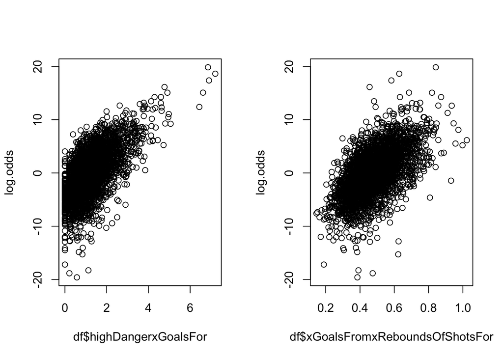

```r
plot(df$highDangerxGoalsFor, log.odds)
plot(df$xGoalsFromxReboundsOfShotsFor, log.odds)
```

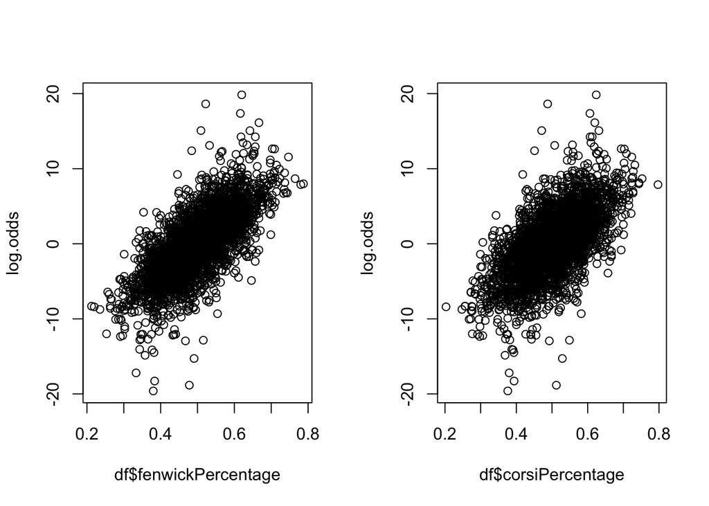

```r
plot(df$fenwickPercentage, log.odds)
plot(df$corsiPercentage, log.odds)
```

There might be a curved relationship between xresult and highDangerxGoalsAgainst, highDangerxGoalsFor, and xGoalsFromxReboundsOfShotsFor.

```r
logreg.vars.poly <- glm(xresult ~ shotAttemptsFor + poly(highDangerxGoalsAgainst, 2) + poly(highDangerxGoalsFor, 2) + poly(xGoalsFromxReboundsOfShotsFor, 2) + fenwickPercentage + playerTeam + opposingTeam + home_or_away, family = binomial, data = df)

anova(logreg.vars, logreg.vars.poly)
```

```
Analysis of Deviance Table

Model 1: xresult ~ shotAttemptsFor + highDangerxGoalsAgainst + highDangerxGoalsFor +
    xGoalsFromxReboundsOfShotsFor + corsiPercentage + fenwickPercentage +
    dZoneGiveawaysFor + playerTeam + opposingTeam + home_or_away
Model 2: xresult ~ shotAttemptsFor + poly(highDangerxGoalsAgainst, 2) +
    poly(highDangerxGoalsFor, 2) + poly(xGoalsFromxReboundsOfShotsFor,
    2) + fenwickPercentage + playerTeam + opposingTeam + home_or_away
  Resid. Df Resid. Dev Df Deviance Pr(>Chi)
1      3033     1272.4
2      3032     1267.2  1   5.2668  0.02174 *
---
Signif. codes:  0 '***' 0.001 '**' 0.01 '*' 0.05 '.' 0.1 ' ' 1
```

This polynomial model has significantly less deviance than the linear terms.

## Multicollinearity

```r
vif(logreg.vars)
```

```
                                  GVIF Df GVIF^(1/(2*Df))
shotAttemptsFor               5.037666  1        2.244475
highDangerxGoalsAgainst       2.751767  1        1.658845
highDangerxGoalsFor           2.624442  1        1.620013
xGoalsFromxReboundsOfShotsFor 3.080859  1        1.755238
corsiPercentage               8.232773  1        2.869281
fenwickPercentage             6.482402  1        2.546056
dZoneGiveawaysFor             1.380221  1        1.174828
playerTeam                    4.501111 32        1.023783
opposingTeam                  4.497947 32        1.023772
home_or_away                  1.921622  1        1.386226
```

Multicollinearity is not an issue.

## Outliers

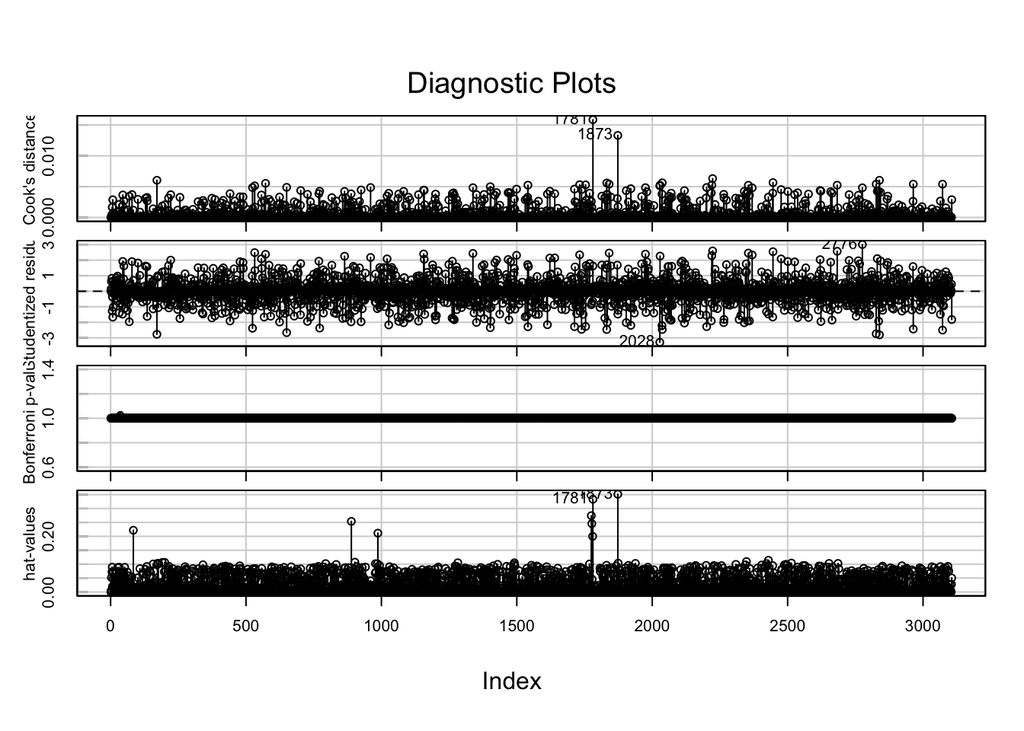

```r
leverage <- hatvalues(logreg.vars)
cd <- cooks.distance(logreg.vars)
car::infIndexPlot(logreg.vars)
```

.03 is a common but conservative threshold for identifying points of possible interest due to high leverage (hat values). Cooks distance > 1 focuses on measuring the influence of points on the model

# Stepwise Variable Selection

```r
logreg.vars.poly$formula
```

```
xresult ~ shotAttemptsFor + poly(highDangerxGoalsAgainst, 2) +
    poly(highDangerxGoalsFor, 2) + poly(xGoalsFromxReboundsOfShotsFor,
    2) + fenwickPercentage + playerTeam + opposingTeam + home_or_away
```

```r
logreg.null <- glm(xresult ~ 1, family = binomial, data = df)

step_out <- step(logreg.null,
  scope = list(lower = logreg.null, upper = logreg.vars),
  method = "both",
  TRACE = 0
)
```

```
Start:  AIC=4307.83
xresult ~ 1

                                Df Deviance    AIC
+ fenwickPercentage              1   3225.4 3229.4
+ corsiPercentage                1   3524.1 3528.1
+ highDangerxGoalsAgainst        1   3575.3 3579.3
+ highDangerxGoalsFor            1   3575.3 3579.3
+ xGoalsFromxReboundsOfShotsFor  1   3606.0 3610.0
+ shotAttemptsFor                1   3767.1 3771.1
+ playerTeam                    32   4093.5 4159.5
+ opposingTeam                  32   4093.5 4159.5
+ home_or_away                   1   4240.4 4244.4
<none>                               4305.8 4307.8
+ dZoneGiveawaysFor              1   4305.6 4309.6

Step:  AIC=3229.37
xresult ~ fenwickPercentage

                                Df Deviance    AIC
+ highDangerxGoalsFor            1   2584.5 2590.5
+ highDangerxGoalsAgainst        1   2584.5 2590.5
+ xGoalsFromxReboundsOfShotsFor  1   3197.6 3203.6
+ corsiPercentage                1   3198.4 3204.4
+ home_or_away                   1   3205.8 3211.8
+ shotAttemptsFor                1   3219.2 3225.2
+ dZoneGiveawaysFor              1   3221.0 3227.0
<none>                               3225.4 3229.4
+ opposingTeam                  32   3173.7 3241.7
+ playerTeam                    32   3173.7 3241.7
- fenwickPercentage              1   4305.8 4307.8

Step:  AIC=2590.45
xresult ~ fenwickPercentage + highDangerxGoalsFor

                                Df Deviance    AIC
+ highDangerxGoalsAgainst        1   1743.7 1751.7
+ home_or_away                   1   2487.1 2495.1
+ shotAttemptsFor                1   2560.9 2568.9
+ corsiPercentage                1   2575.7 2583.7
```

[output cut: 59 more lines]

```
xresult ~ fenwickPercentage + highDangerxGoalsFor + highDangerxGoalsAgainst +
    home_or_away + xGoalsFromxReboundsOfShotsFor + shotAttemptsFor

                                Df Deviance    AIC
<none>                               1361.5 1375.5
+ corsiPercentage                1   1359.8 1375.8
+ dZoneGiveawaysFor              1   1361.5 1377.5
- shotAttemptsFor                1   1366.4 1378.4
+ playerTeam                    32   1315.6 1393.6
- xGoalsFromxReboundsOfShotsFor  1   1385.2 1397.2
+ opposingTeam                  32   1320.9 1398.9
- fenwickPercentage              1   1702.4 1714.4
- home_or_away                   1   1728.4 1740.4
- highDangerxGoalsFor            1   2335.2 2347.2
- highDangerxGoalsAgainst        1   2460.1 2472.1
```

```r
step_out_poly <- step(logreg.null,
  scope = list(lower = logreg.null, upper = logreg.vars.poly),
  method = "both",
  TRACE = 0
)
```

```
Start:  AIC=4307.83
xresult ~ 1

                                         Df Deviance    AIC
+ fenwickPercentage                       1   3225.4 3229.4
+ poly(highDangerxGoalsAgainst, 2)        2   3571.7 3577.7
+ poly(highDangerxGoalsFor, 2)            2   3571.7 3577.7
+ poly(xGoalsFromxReboundsOfShotsFor, 2)  2   3593.0 3599.0
+ shotAttemptsFor                         1   3767.1 3771.1
+ playerTeam                             32   4093.5 4159.5
+ opposingTeam                           32   4093.5 4159.5
+ home_or_away                            1   4240.4 4244.4
<none>                                        4305.8 4307.8

Step:  AIC=3229.37
xresult ~ fenwickPercentage

                                         Df Deviance    AIC
+ poly(highDangerxGoalsFor, 2)            2   2583.7 2591.7
+ poly(highDangerxGoalsAgainst, 2)        2   2583.7 2591.7
+ poly(xGoalsFromxReboundsOfShotsFor, 2)  2   3197.2 3205.2
+ home_or_away                            1   3205.8 3211.8
+ shotAttemptsFor                         1   3219.2 3225.2
<none>                                        3225.4 3229.4
+ opposingTeam                           32   3173.7 3241.7
+ playerTeam                             32   3173.7 3241.7
- fenwickPercentage                       1   4305.8 4307.8

Step:  AIC=2591.71
xresult ~ fenwickPercentage + poly(highDangerxGoalsFor, 2)

                                         Df Deviance    AIC
+ poly(highDangerxGoalsAgainst, 2)        2   1739.5 1751.5
+ home_or_away                            1   2486.4 2496.4
+ shotAttemptsFor                         1   2559.8 2569.8
+ poly(xGoalsFromxReboundsOfShotsFor, 2)  2   2577.7 2589.7
<none>                                        2583.7 2591.7
+ opposingTeam                           32   2531.0 2603.0
+ playerTeam                             32   2544.4 2616.4
- poly(highDangerxGoalsFor, 2)            2   3225.4 3229.4
```

[output cut: 48 more lines]

```
Step:  AIC=1376.93
xresult ~ fenwickPercentage + poly(highDangerxGoalsFor, 2) +
    poly(highDangerxGoalsAgainst, 2) + home_or_away + poly(xGoalsFromxReboundsOfShotsFor,
    2) + shotAttemptsFor

                                         Df Deviance    AIC
<none>                                        1356.9 1376.9
- shotAttemptsFor                         1   1361.6 1379.6
+ playerTeam                             32   1310.6 1394.6
- poly(xGoalsFromxReboundsOfShotsFor, 2)  2   1379.6 1395.6
+ opposingTeam                           32   1315.7 1399.7
- fenwickPercentage                       1   1692.7 1710.7
- home_or_away                            1   1723.7 1741.7
- poly(highDangerxGoalsFor, 2)            2   2333.1 2349.1
- poly(highDangerxGoalsAgainst, 2)        2   2459.1 2475.1
```

```r
logreg.vars.poly$formula
```

```
xresult ~ shotAttemptsFor + poly(highDangerxGoalsAgainst, 2) +
    poly(highDangerxGoalsFor, 2) + poly(xGoalsFromxReboundsOfShotsFor,
    2) + fenwickPercentage + playerTeam + opposingTeam + home_or_away
```

```r
step_out$formula
```

```
xresult ~ fenwickPercentage + highDangerxGoalsFor + highDangerxGoalsAgainst +
    home_or_away + xGoalsFromxReboundsOfShotsFor + shotAttemptsFor
```

```r
step_out_poly$formula
```

```
xresult ~ fenwickPercentage + poly(highDangerxGoalsFor, 2) +
    poly(highDangerxGoalsAgainst, 2) + home_or_away + poly(xGoalsFromxReboundsOfShotsFor,
    2) + shotAttemptsFor
```

Stepwise excluded playerTeam and opposingTeam

# Model Selection

To compare final models, we do the following:

## Logistic Model

```r
# fit a model on all data
logreg <- glm(xresult ~ fenwickPercentage + highDangerxGoalsFor +
  highDangerxGoalsAgainst + xGoalsFromxReboundsOfShotsFor + shotAttemptsFor + home_or_away, family = binomial, data = df)

summary(logreg)
```

```
Call:
glm(formula = xresult ~ fenwickPercentage + highDangerxGoalsFor +
    highDangerxGoalsAgainst + xGoalsFromxReboundsOfShotsFor +
    shotAttemptsFor + home_or_away, family = binomial, data = df)

Coefficients:
                               Estimate Std. Error z value Pr(>|z|)
(Intercept)                   -16.52984    0.80783 -20.462  < 2e-16 ***
fenwickPercentage              28.60344    1.83210  15.612  < 2e-16 ***
highDangerxGoalsFor             3.47571    0.16830  20.652  < 2e-16 ***
highDangerxGoalsAgainst        -3.68239    0.17340 -21.236  < 2e-16 ***
xGoalsFromxReboundsOfShotsFor   5.22170    1.08885   4.796 1.62e-06 ***
shotAttemptsFor                -0.02431    0.01107  -2.197   0.0281 *
home_or_awayHOME                2.89879    0.17990  16.113  < 2e-16 ***
---
Signif. codes:  0 '***' 0.001 '**' 0.01 '*' 0.05 '.' 0.1 ' ' 1

(Dispersion parameter for binomial family taken to be 1)

    Null deviance: 4305.8  on 3105  degrees of freedom
Residual deviance: 1361.5  on 3099  degrees of freedom
AIC: 1375.5

Number of Fisher Scoring iterations: 7
```

### Threshold Tuning

- True positive: predicted majority wins & actual majority wins
- True negatives: predicted majority loss & actual majority losses
- False positives: predicted majority wins & actual majority losses

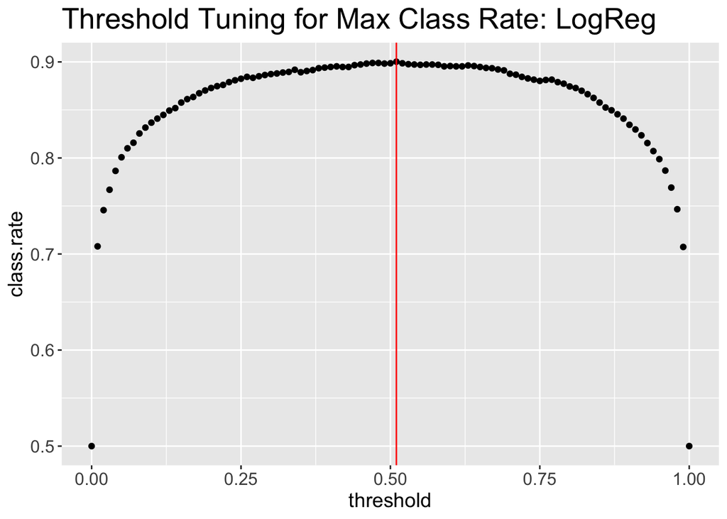

```r
probs <- predict(logreg, type = "response")
threshold <- seq(0, 1, .01)

tpr <- tnr <- fpr <- class.rate <- err.rate <- rep(0, length(threshold))

for (i in seq_along(threshold)) {
  yhat <- rep(NA_character_, nrow(df))
  yhat <- ifelse(probs >= threshold[[i]], 1, 0)

  class.rate[i] <- mean(yhat == df$xresult)
  err.rate[i] <- 1 - class.rate[i]

  tpr[[i]] <- sum((yhat == 1) & (df$xresult == 1)) / sum(df$xresult == 1)
  tnr[[i]] <- sum((yhat == 0) & (df$xresult == 0)) / sum(df$xresult == 0)
  fpr[[i]] <- sum((yhat == 1) & (df$xresult == 0)) / sum(df$xresult == 0)
}

ggplot(
  tibble(threshold, class.rate),
  aes(threshold, class.rate)
) +
  geom_point() +
  geom_vline(xintercept = threshold[which.max(class.rate)], color = "red") +
  labs(title = "Threshold Tuning for Max Class Rate: LogReg") +
  theme(
    plot.title = element_text(size = 20),
    plot.subtitle = element_text(size = 15),
    axis.title = element_text(size = 14),
    axis.text = element_text(size = 12)
  )
```

```r
png("threshold_tune_logreg.png", width = 500, height = 400)
ggplot(
  tibble(threshold, class.rate),
  aes(threshold, class.rate)
) +
  geom_point() +
  geom_vline(xintercept = threshold[which.max(class.rate)], color = "red") +
  labs(title = "Threshold Tuning for Max Class Rate: LogReg") +
  theme(
    plot.title = element_text(size = 20),
    plot.subtitle = element_text(size = 15),
    axis.title = element_text(size = 14),
    axis.text = element_text(size = 12)
  )
```

```r
best_threshold <- threshold[which.max(class.rate)]
best_threshold
```

```
[1] 0.51
```

### ROC Curve

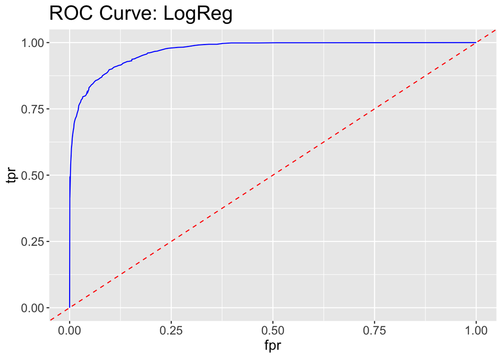

```r
ggplot(
  tibble(fpr, tpr),
  aes(x = fpr, y = tpr)
) +
  geom_line(color = "blue") +
  geom_abline(slope = 1, intercept = 0, linetype = "dashed", color = "red") +
  labs(title = "ROC Curve: LogReg") +
  theme(
    plot.title = element_text(size = 20),
    plot.subtitle = element_text(size = 15),
    axis.title = element_text(size = 14),
    axis.text = element_text(size = 12)
  )
```

```r
pred <- ROCR::prediction(predict(logreg, type = "response"), df$xresult)
ROCR::performance(pred, "auc")@y.values[[1]]
```

```
[1] 0.9703865
```

```r
png("roccurve_logreg.png", width = 300, height = 400)
ggplot(
  tibble(fpr, tpr),
  aes(x = fpr, y = tpr)
) +
  geom_line(color = "blue") +
  geom_abline(slope = 1, intercept = 0, linetype = "dashed", color = "red") +
  labs(title = "ROC Curve: LogReg") +
  theme(
    plot.title = element_text(size = 20),
    plot.subtitle = element_text(size = 15),
    axis.title = element_text(size = 14),
    axis.text = element_text(size = 12)
  )
```

### Test/Train Split

```r
# Data split & model fit
set.seed(123)
n <- nrow(df)
z <- sample(n, n * 0.7)

train <- df[z, ]
test <- df[-z, ]

logreg.train <- glm(xresult ~ fenwickPercentage + highDangerxGoalsFor +
  highDangerxGoalsAgainst + xGoalsFromxReboundsOfShotsFor + shotAttemptsFor + home_or_away, family = binomial, data = train)

probs <- predict(logreg.train, newdata = test, type = "response")
classes <- ifelse(probs > best_threshold, 1, 0)

logreg.tts.class.rate <- mean(classes == test$xresult)
logreg.tts.tpr <- sum(classes == 1 & test$xresult == 1) / sum(test$xresult == 1)
logreg.tts.tnr <- sum(classes == 0 & test$xresult == 0) / sum(test$xresult == 0)

logreg.tts.class.rate
```

```
[1] 0.8905579
```

```r
logreg.tts.tpr
```

```
[1] 0.8831967
```

```r
logreg.tts.tnr
```

```
[1] 0.8986486
```

### CV

```r
L <- function(Y, p) {
  mean(1 * (Y == 1 & p <= best_threshold) | (1 * (Y == 0 & p > best_threshold)),
    na.rm = TRUE
  )
}

set.seed(123)
cv.glm(df, logreg, cost = L, K = 10)$delta
```

```
[1] 0.10141661 0.09993567
```

```r
logreg.cvK10.class.rate <- round(1 - cv.glm(df, logreg, cost = L, K = 10)$delta[2], 3)
logreg.cvK10.class.rate
```

```
[1] 0.898
```

## Logistic Model (Polynomial Terms)

```r
logreg.poly <- glm(xresult ~ fenwickPercentage + poly(highDangerxGoalsFor, 2) +
  poly(highDangerxGoalsAgainst, 2) + poly(
    xGoalsFromxReboundsOfShotsFor,
    2
  ) + shotAttemptsFor + home_or_away, family = binomial, data = df)

summary(logreg.poly)
```

```
Call:
glm(formula = xresult ~ fenwickPercentage + poly(highDangerxGoalsFor,
    2) + poly(highDangerxGoalsAgainst, 2) + poly(xGoalsFromxReboundsOfShotsFor,
    2) + shotAttemptsFor + home_or_away, family = binomial, data = df)

Coefficients:
                                          Estimate Std. Error z value Pr(>|z|)
(Intercept)                              -14.32655    0.92519 -15.485  < 2e-16
fenwickPercentage                         28.68901    1.84844  15.521  < 2e-16
poly(highDangerxGoalsFor, 2)1            157.93736    9.31455  16.956  < 2e-16
poly(highDangerxGoalsFor, 2)2            -14.18766    9.75337  -1.455   0.1458
poly(highDangerxGoalsAgainst, 2)1       -166.01362    9.58833 -17.314  < 2e-16
poly(highDangerxGoalsAgainst, 2)2         16.86664    9.82070   1.717   0.0859
poly(xGoalsFromxReboundsOfShotsFor, 2)1   34.74250    7.43904   4.670 3.01e-06
poly(xGoalsFromxReboundsOfShotsFor, 2)2    1.45466    5.99751   0.243   0.8084
shotAttemptsFor                           -0.02399    0.01110  -2.162   0.0307
home_or_awayHOME                           2.91351    0.18080  16.115  < 2e-16

(Intercept)                             ***
fenwickPercentage                       ***
poly(highDangerxGoalsFor, 2)1           ***
poly(highDangerxGoalsFor, 2)2
poly(highDangerxGoalsAgainst, 2)1       ***
poly(highDangerxGoalsAgainst, 2)2       .
poly(xGoalsFromxReboundsOfShotsFor, 2)1 ***
poly(xGoalsFromxReboundsOfShotsFor, 2)2
shotAttemptsFor                         *
home_or_awayHOME                        ***
---
Signif. codes:  0 '***' 0.001 '**' 0.01 '*' 0.05 '.' 0.1 ' ' 1

(Dispersion parameter for binomial family taken to be 1)

    Null deviance: 4305.8  on 3105  degrees of freedom
Residual deviance: 1356.9  on 3096  degrees of freedom
AIC: 1376.9

Number of Fisher Scoring iterations: 7
```

### Threshold Tuning

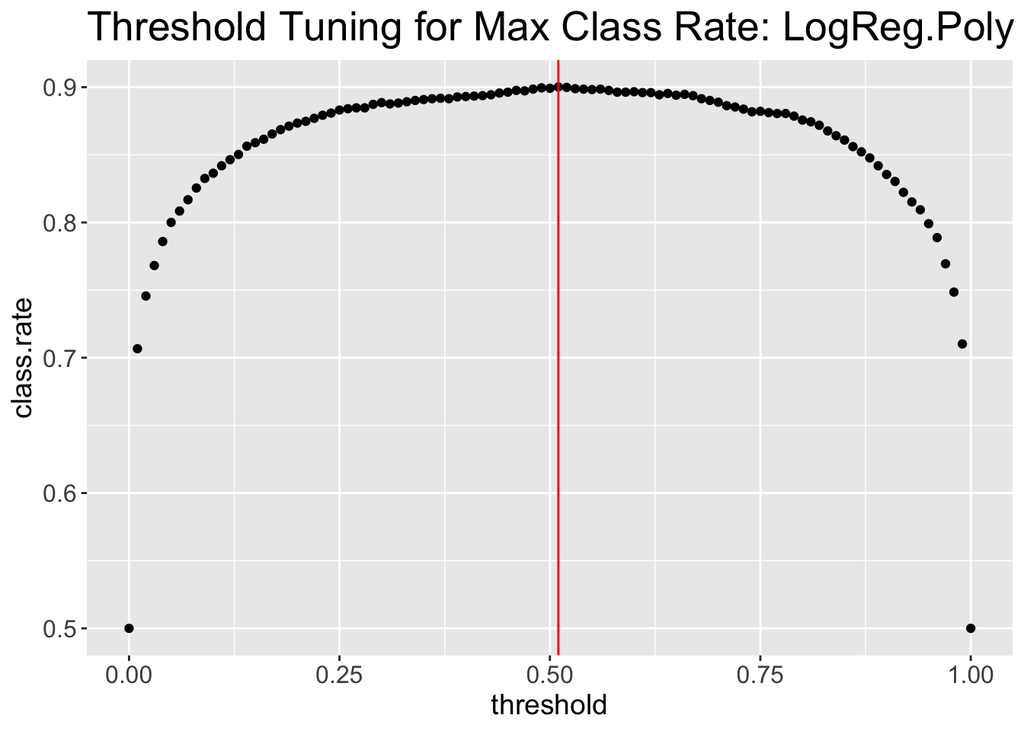

```r
probs <- predict(logreg.poly, type = "response")
threshold <- seq(0, 1, .01)

tpr <- tnr <- fpr <- class.rate <- err.rate <- rep(0, length(threshold))

for (i in seq_along(threshold)) {
  yhat <- rep(NA_character_, nrow(df))
  yhat <- ifelse(probs >= threshold[[i]], 1, 0)

  class.rate[i] <- mean(yhat == df$xresult)
  err.rate[i] <- 1 - class.rate[i]

  tpr[[i]] <- sum((yhat == 1) & (df$xresult == 1)) / sum(df$xresult == 1)
  tnr[[i]] <- sum((yhat == 0) & (df$xresult == 0)) / sum(df$xresult == 0)
  fpr[[i]] <- sum((yhat == 1) & (df$xresult == 0)) / sum(df$xresult == 0)
}

ggplot(
  tibble(threshold, class.rate),
  aes(threshold, class.rate)
) +
  geom_point() +
  geom_vline(xintercept = threshold[which.max(class.rate)], color = "red") +
  labs(title = "Threshold Tuning for Max Class Rate: LogReg.Poly") +
  theme(
    plot.title = element_text(size = 20),
    plot.subtitle = element_text(size = 15),
    axis.title = element_text(size = 14),
    axis.text = element_text(size = 12)
  )
```

```r
png("threshold_tune_logregPoly.png", width = 500, height = 500)
ggplot(
  tibble(threshold, class.rate),
  aes(threshold, class.rate)
) +
  geom_point() +
  geom_vline(xintercept = threshold[which.max(class.rate)], color = "red") +
  labs(title = "Threshold Tuning for Max Class Rate: LogReg.Poly") +
  theme(
    plot.title = element_text(size = 20),
    plot.subtitle = element_text(size = 15),
    axis.title = element_text(size = 14),
    axis.text = element_text(size = 12)
  )
```

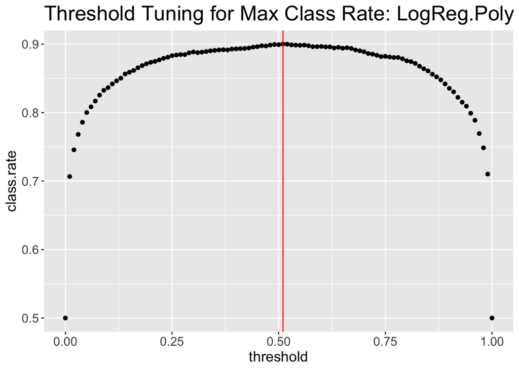

```r
ggplot(
  tibble(threshold, class.rate),
  aes(threshold, class.rate)
) +
  geom_point() +
  geom_vline(xintercept = threshold[which.max(class.rate)], color = "red") +
  labs(title = "Threshold Tuning for Max Class Rate: LogReg.Poly") +
  theme(
    plot.title = element_text(size = 20),
    plot.subtitle = element_text(size = 15),
    axis.title = element_text(size = 14),
    axis.text = element_text(size = 12)
  )
```

```r
best_threshold <- threshold[which.max(class.rate)]
best_threshold
```

```
[1] 0.51
```

### ROC Curve

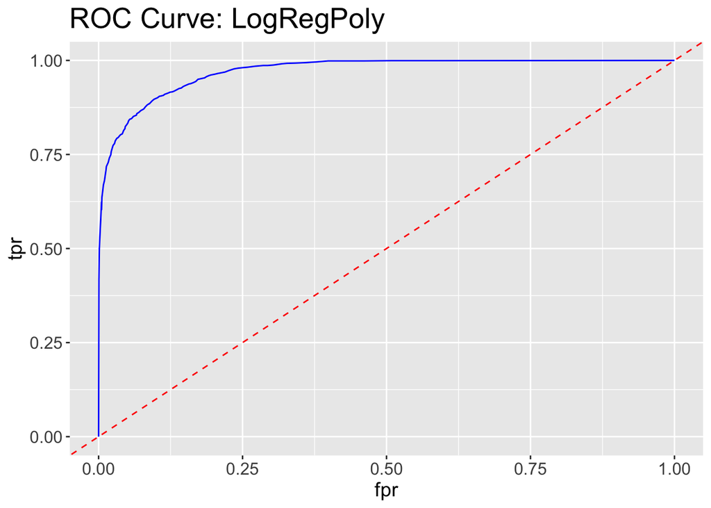

```r
ggplot(
  tibble(fpr, tpr),
  aes(x = fpr, y = tpr)
) +
  geom_line(color = "blue") +
  geom_abline(slope = 1, intercept = 0, linetype = "dashed", color = "red") +
  labs(title = "ROC Curve: LogRegPoly") +
  theme(
    plot.title = element_text(size = 20),
    plot.subtitle = element_text(size = 15),
    axis.title = element_text(size = 14),
    axis.text = element_text(size = 12)
  )
```

```r
pred <- ROCR::prediction(predict(logreg.poly, type = "response"), df$xresult)
ROCR::performance(pred, "auc")@y.values[[1]]
```

```
[1] 0.9705984
```

```r
png("roccurve_logregPoly.png", width = 400, height = 200)
ggplot(
  tibble(fpr, tpr),
  aes(x = fpr, y = tpr)
) +
  geom_line(color = "blue") +
  geom_abline(slope = 1, intercept = 0, linetype = "dashed", color = "red") +
  labs(title = "ROC Curve: LogRegPoly") +
  theme(
    plot.title = element_text(size = 20),
    plot.subtitle = element_text(size = 15),
    axis.title = element_text(size = 14),
    axis.text = element_text(size = 12)
  )
```

### Test/Train Split

```r
logreg.poly.train <- glm(xresult ~ fenwickPercentage + poly(highDangerxGoalsFor, 2) +
  poly(highDangerxGoalsAgainst, 2) + poly(xGoalsFromxReboundsOfShotsFor, 2) + shotAttemptsFor + home_or_away, family = binomial, data = train)

probs <- predict(logreg.poly.train, newdata = test, type = "response")
classes <- ifelse(probs > best_threshold, 1, 0)

logreg.poly.tts.class.rate <- mean(classes == test$xresult)
logreg.poly.tts.tpr <- sum(classes == 1 & test$xresult == 1) / sum(test$xresult == 1)
logreg.poly.tts.tnr <- sum(classes == 0 & test$xresult == 0) / sum(test$xresult == 0)

logreg.poly.tts.class.rate
```

```
[1] 0.8862661
```

```r
logreg.poly.tts.tpr
```

```
[1] 0.8790984
```

```r
logreg.poly.tts.tnr
```

```
[1] 0.8941441
```

### CV

```r
set.seed(123)
cv.glm(df, logreg.poly, cost = L, K = 10)$delta
```

```
[1] 0.1027044 0.1020920
```

```r
logreg.poly.cvK10.class.rate <- round(1 - cv.glm(df, logreg.poly, cost = L, K = 10)$delta[2], 3)
logreg.poly.cvK10.class.rate
```

```
[1] 0.899
```

## Linear Discriminant Analysis

```r
lda.fit <- lda(xresult ~ fenwickPercentage + highDangerxGoalsFor +
  highDangerxGoalsAgainst + xGoalsFromxReboundsOfShotsFor + shotAttemptsFor + home_or_away, data = df, CV = FALSE)
```

### Threshold Tuning

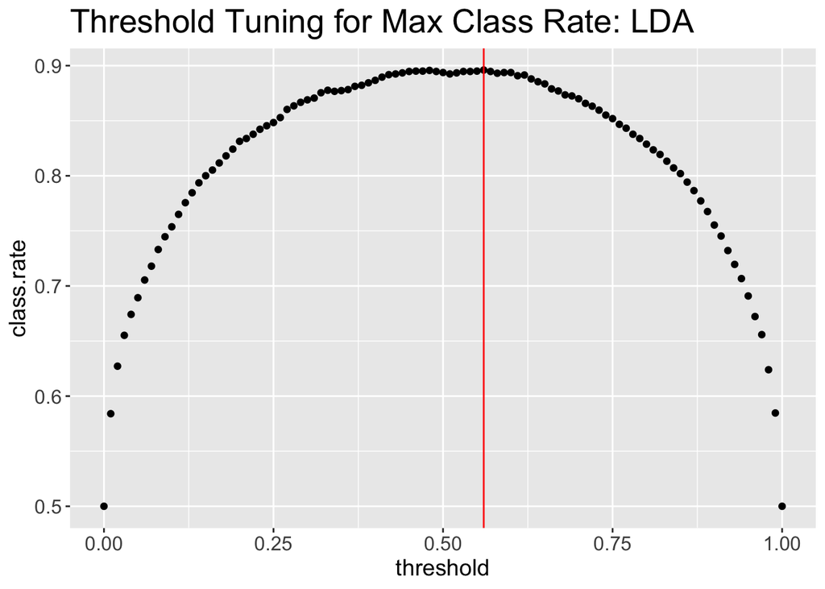

```r
probs <- predict(lda.fit)$posterior[, 2]
threshold <- seq(0, 1, .01)

tpr <- tnr <- fpr <- class.rate <- err.rate <- rep(0, length(threshold))

for (i in seq_along(threshold)) {
  yhat <- rep(NA_character_, nrow(df))
  yhat <- ifelse(probs >= threshold[[i]], 1, 0)

  class.rate[i] <- mean(yhat == df$xresult)
  err.rate[i] <- 1 - class.rate[i]

  tpr[[i]] <- sum((yhat == 1) & (df$xresult == 1)) / sum(df$xresult == 1)
  tnr[[i]] <- sum((yhat == 0) & (df$xresult == 0)) / sum(df$xresult == 0)
  fpr[[i]] <- sum((yhat == 1) & (df$xresult == 0)) / sum(df$xresult == 0)
}

ggplot(
  tibble(threshold, class.rate),
  aes(threshold, class.rate)
) +
  geom_point() +
  geom_vline(xintercept = threshold[which.max(class.rate)], color = "red") +
  labs(title = "Threshold Tuning for Max Class Rate: LDA") +
  theme(
    plot.title = element_text(size = 20),
    plot.subtitle = element_text(size = 15),
    axis.title = element_text(size = 14),
    axis.text = element_text(size = 12)
  )
```

```r
best_threshold <- threshold[which.max(class.rate)]
best_threshold
```

```
[1] 0.56
```

### ROC Curve

[figure not shown]

```r
ggplot(
  tibble(fpr, tpr),
  aes(x = fpr, y = tpr)
) +
  geom_line(color = "blue") +
  geom_abline(slope = 1, intercept = 0, linetype = "dashed", color = "red") +
  labs(title = "ROC Curve: QDA") +
  theme(
    plot.title = element_text(size = 20),
    plot.subtitle = element_text(size = 15),
    axis.title = element_text(size = 14),
    axis.text = element_text(size = 12)
  )
```

```r
pred <- ROCR::prediction(predict(lda.fit)$posterior[, 2], df$xresult)
ROCR::performance(pred, "auc")@y.values[[1]]
```

```
[1] 0.9693757
```

### Test/Train Split

```r
lda.fit.train <- lda(xresult ~ fenwickPercentage + highDangerxGoalsFor +
  highDangerxGoalsAgainst + xGoalsFromxReboundsOfShotsFor + shotAttemptsFor + home_or_away, data = train, CV = FALSE)

probs <- predict(lda.fit.train, test)$posterior[, 2]
classes <- ifelse(probs > best_threshold, 1, 0)

lda.fit.tts.class.rate <- mean(classes == test$xresult)
lda.fit.tts.tpr <- sum(classes == 1 & test$xresult == 1) / sum(test$xresult == 1)
lda.fit.tts.tnr <- sum(classes == 0 & test$xresult == 0) / sum(test$xresult == 0)

lda.fit.tts.class.rate
```

```
[1] 0.8927039
```

```r
lda.fit.tts.tpr
```

```
[1] 0.8586066
```

```r
lda.fit.tts.tnr
```

```
[1] 0.9301802
```

### CV

```r
lda.fit.cv <- lda(xresult ~ fenwickPercentage + highDangerxGoalsFor +
  highDangerxGoalsAgainst + xGoalsFromxReboundsOfShotsFor + shotAttemptsFor + home_or_away, data = df, CV = TRUE)

lda.fit.cv.class.rate <- round(1 - sum(lda.fit.cv$class != df$xresult) / nrow(df), 3)
lda.fit.cv.class.rate
```

```
[1] 0.893
```

## Quadratic Discriminant Analysis

```r
qda.fit <- qda(xresult ~ fenwickPercentage + highDangerxGoalsFor +
  highDangerxGoalsAgainst + xGoalsFromxReboundsOfShotsFor + shotAttemptsFor + home_or_away, data = df, CV = FALSE)
```

### Threshold Tuning

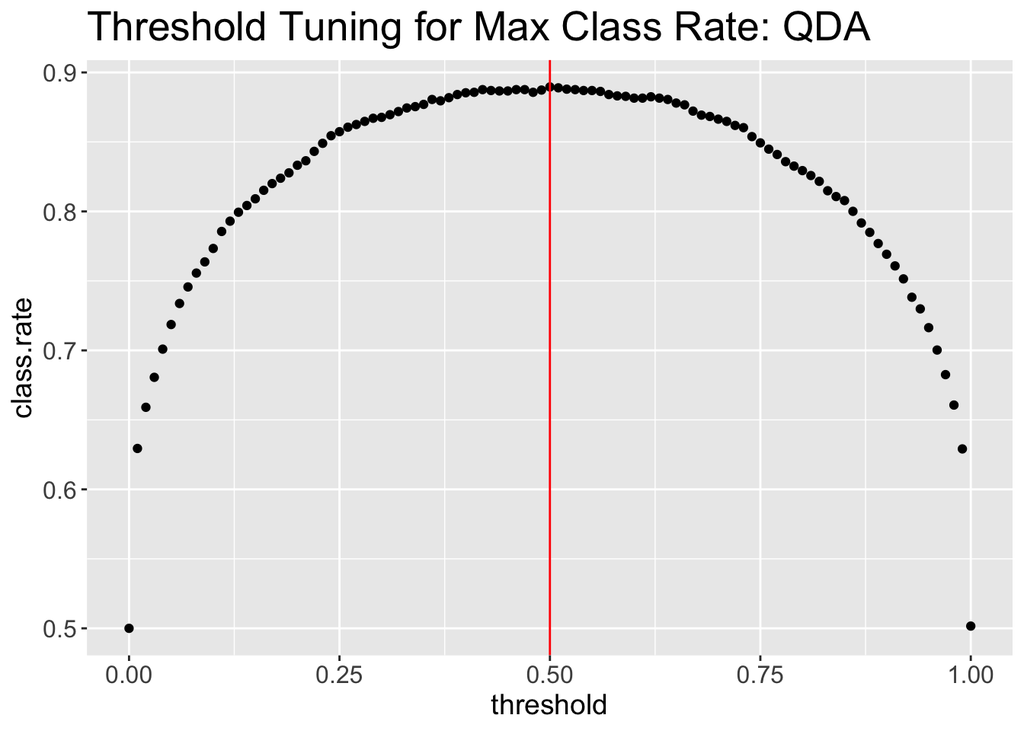

```r
probs <- predict(qda.fit)$posterior[, 2]
threshold <- seq(0, 1, .01)

tpr <- tnr <- fpr <- class.rate <- err.rate <- rep(0, length(threshold))

for (i in seq_along(threshold)) {
  yhat <- rep(NA_character_, nrow(df))
  yhat <- ifelse(probs >= threshold[[i]], 1, 0)

  class.rate[i] <- mean(yhat == df$xresult)
  err.rate[i] <- 1 - class.rate[i]

  tpr[[i]] <- sum((yhat == 1) & (df$xresult == 1)) / sum(df$xresult == 1)
  tnr[[i]] <- sum((yhat == 0) & (df$xresult == 0)) / sum(df$xresult == 0)
  fpr[[i]] <- sum((yhat == 1) & (df$xresult == 0)) / sum(df$xresult == 0)
}

ggplot(
  tibble(threshold, class.rate),
  aes(threshold, class.rate)
) +
  geom_point() +
  geom_vline(xintercept = threshold[which.max(class.rate)], color = "red") +
  labs(title = "Threshold Tuning for Max Class Rate: QDA") +
  theme(
    plot.title = element_text(size = 20),
    plot.subtitle = element_text(size = 15),
    axis.title = element_text(size = 14),
    axis.text = element_text(size = 12)
  )
```

```r
best_threshold <- threshold[which.max(class.rate)]
best_threshold
```

```
[1] 0.5
```

### ROC Curve

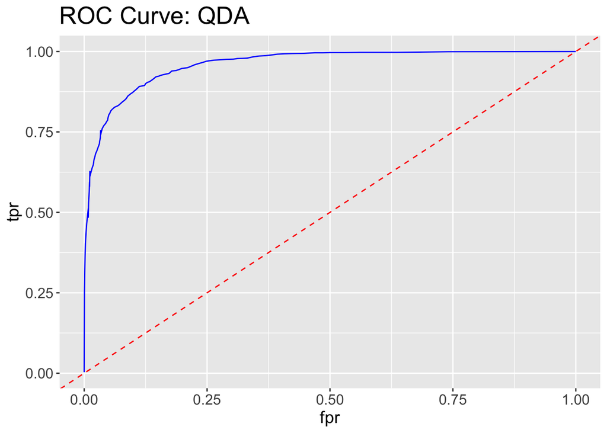

```r
ggplot(
  tibble(fpr, tpr),
  aes(x = fpr, y = tpr)
) +
  geom_line(color = "blue") +
  geom_abline(slope = 1, intercept = 0, linetype = "dashed", color = "red") +
  labs(title = "ROC Curve: QDA") +
  theme(
    plot.title = element_text(size = 20),
    plot.subtitle = element_text(size = 15),
    axis.title = element_text(size = 14),
    axis.text = element_text(size = 12)
  )
```

```r
pred <- ROCR::prediction(predict(qda.fit)$posterior[, 2], df$xresult)
ROCR::performance(pred, "auc")@y.values[[1]]
```

```
[1] 0.9604936
```

### Test/Train Split

```r
qda.fit.train <- qda(xresult ~ fenwickPercentage + highDangerxGoalsFor +
  highDangerxGoalsAgainst + xGoalsFromxReboundsOfShotsFor + shotAttemptsFor + home_or_away, data = train, CV = FALSE)

probs <- predict(qda.fit.train, test)$posterior[, 2]
classes <- ifelse(probs > best_threshold, 1, 0)

qda.fit.tts.class.rate <- mean(classes == test$xresult)
qda.fit.tts.tpr <- sum(classes == 1 & test$xresult == 1) / sum(test$xresult == 1)
qda.fit.tts.tnr <- sum(classes == 0 & test$xresult == 0) / sum(test$xresult == 0)

qda.fit.tts.class.rate
```

```
[1] 0.888412
```

```r
qda.fit.tts.tpr
```

```
[1] 0.8831967
```

```r
qda.fit.tts.tnr
```

```
[1] 0.8941441
```

### CV

```r
qda.fit.cv <- qda(xresult ~ fenwickPercentage + highDangerxGoalsFor +
  highDangerxGoalsAgainst + xGoalsFromxReboundsOfShotsFor + shotAttemptsFor + home_or_away, data = df, CV = TRUE)

qda.fit.cv.class.rate <- round(1 - sum(qda.fit.cv$class != df$xresult) / nrow(df), 3)
qda.fit.cv.class.rate
```

```
[1] 0.886
```

## KNN

### Best K & Test/Train Split

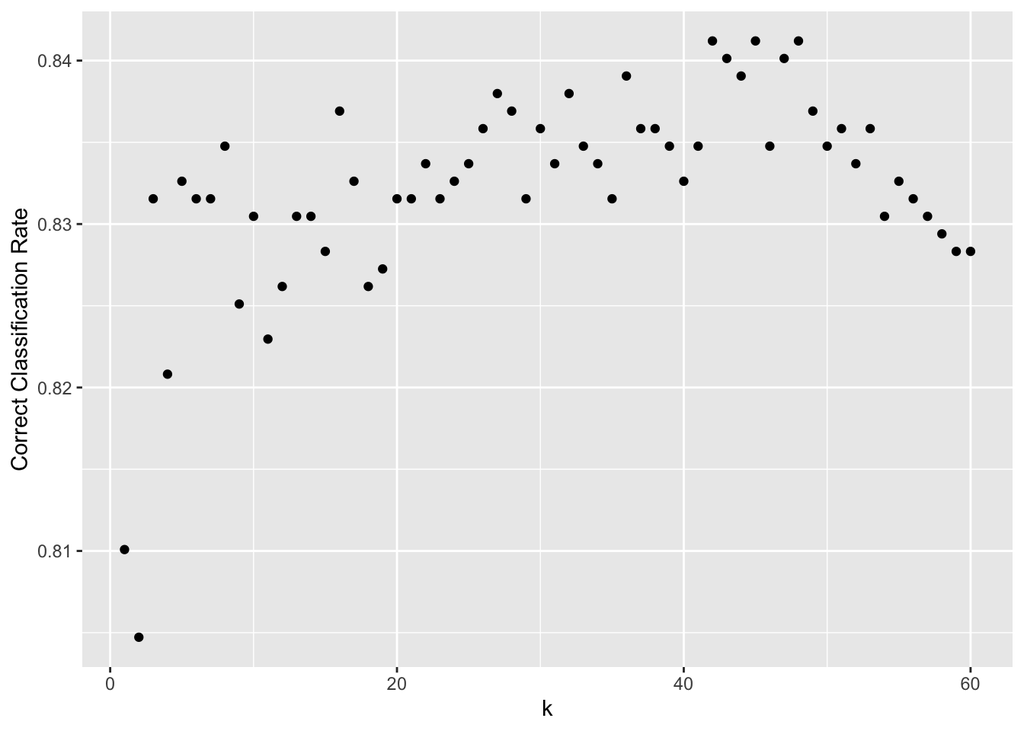

```r
X <- c("fenwickPercentage", "highDangerxGoalsFor", "highDangerxGoalsAgainst", "xGoalsFromxReboundsOfShotsFor", "shotAttemptsFor", "home_or_away")

train$home_or_away <- as.numeric(as.factor(train$home_or_away))
test$home_or_away <- as.numeric(as.factor(test$home_or_away))


x_train <- train[, X]
x_test <- test[, X]
y_train <- train$xresult
y_test <- test$xresult

knn_rate <- rep(0, 60)

for (k in 1:60) {
  set.seed(123)
  knn_fit <- knn(x_train, x_test, y_train, k)
  knn_rate[k] <- mean(knn_fit == y_test)
}

ggplot(
  tibble(k = seq(1, 60), `Correct Classification Rate` = knn_rate),
  aes(k, `Correct Classification Rate`)
) +
  geom_point()
```

```r
which.max(knn_rate)
```

```
[1] 42
```

```r
knn_fit <- knn(x_train, x_test, y_train, 42)
knn.class.rate <- mean(knn_fit == y_test)
knn.tpr <- sum((knn_fit == 1) & (y_test == 1)) / sum(y_test == 1)
knn.tnr <- sum((knn_fit == 0) & (y_test == 0)) / sum(y_test == 0)
```

# Summary Model Performance

**Classification**

- logreg.tts.class.rate
- logreg.cvK10.class.rate
- logreg.poly.tts.class.rate
- logreg.poly.cvK10.class.rate
- lda.fit.tts.class.rate
- lda.fit.cv.class.rate
- qda.fit.tts.class.rate
- qda.fit.cv.class.rate
- knn.class.rate

**Sensitivity (TPR)**

- logreg.tts.tpr
- logreg.poly.tts.tpr
- lda.fit.tts.tpr
- qda.fit.tts.tpr
- knn.tpr

**Specificity (TNR)**

- logreg.tts.tnr
- logreg.poly.tts.tnr
- lda.fit.tts.tnr
- qda.fit.tts.tnr
- knn.tnr

```r
data.frame(
  model = c(
    "LogReg Test/Train",
    "LogReg (Polynomial) Test/Train",
    "LogReg K-Fold 10",
    "LogReg (Polynomial) K-Fold 10",
    "LDA Test/Train",
    "LDA LOOCV",
    "QDA Test/Train",
    "QDA LOOCV",
    "KNN K=42"
  ),
  class.rate = c(
    round(logreg.tts.class.rate,3),
    round(logreg.poly.tts.class.rate,3),
    round(logreg.cvK10.class.rate,3),
    round(logreg.poly.cvK10.class.rate,3),
    round(lda.fit.tts.class.rate,3),
    round(lda.fit.cv.class.rate,3),
    round(qda.fit.tts.class.rate,3),
    round(qda.fit.cv.class.rate,3),
    round(knn.class.rate,3)
  )
)
```

```
                           model class.rate
1              LogReg Test/Train      0.891
2 LogReg (Polynomial) Test/Train      0.886
3               LogReg K-Fold 10      0.898
4  LogReg (Polynomial) K-Fold 10      0.899
5                 LDA Test/Train      0.893
6                      LDA LOOCV      0.893
7                 QDA Test/Train      0.888
8                      QDA LOOCV      0.886
9                       KNN K=42      0.841
```

```r
data.frame(
  model = c(
    "LogReg",
    "LogReg (Polynomial)",
    "LDA",
    "QDA",
    "KNN K=42"
  ),
  tpr = c(
    round(logreg.tts.tpr,3),
    round(logreg.poly.tts.tpr,3),
    round(lda.fit.tts.tpr,3),
    round(qda.fit.tts.tpr,3),
    round(knn.tpr,3)
  ),
  tnr = c(
    round(logreg.tts.tnr,3),
    round(logreg.poly.tts.tnr,3),
    round(lda.fit.tts.tnr,3),
    round(qda.fit.tts.tnr,3),
    round(knn.tnr,3)
  )
)
```

```
                model   tpr   tnr
1              LogReg 0.883 0.899
2 LogReg (Polynomial) 0.879 0.894
3                 LDA 0.859 0.930
4                 QDA 0.883 0.894
5            KNN K=42 0.844 0.838
```